# MATH1324 Assignment 4

Alistair Grevis-James s3644119

# Statistical Evaluation of Mice Protein Expression Data Set

### Executive Summary

The data (‘Mice Protein Expression Data Set’) was collected online (UCI Machine Learning), consisting of 1080 observations over 82 variables. These data consisted of continuous numerical protein expression data, and categorical data including mouse identification and variable exposure. After data exploration, visualization and data preprocessing, two modes of statistical analysis were employed. The first was linear regression analysis. Prior to fitting any regression, a scatter plot assessing the bi variate relationship between the relevant proteins was inspected. In the three relationships considered, the scatter plots demonstrated evidence of a positive linear relationship. A linear regression model was fitted to predict the dependent variable, ITSN1_N, using measurements of DYRK1A_N over all classes of mice. The overall regression model was statistically significant, F(1,1063)=6779.2, p<.001, and explained 86.5% of the variability in ITSN1_N.A linear regression model was fitted to predict the dependent variable, pERK_N, using measurements of DYRK1A_N over all classes of mice. The overall regression model was statistically significant, F(1,1063)=6976.3, p<.001, and explained 86.8% of the variability in pERK_N. A linear regression model was fitted to predict the dependent variable, pERK_N, using measurements of BRAF_N over all classes of mice. The overall regression model was statistically significant, F(1,1063)=4529.1, p<.001, and explained 81.0% of the variability in pERK_N. For all three regression models the 95% CI for the intercept did not pass through 0, which simply indicated the presence of a background, or base, level of protein. For the class c-CS-s, 7 paired t-tests were performed. For ARC_N and BRAF_N (n = 120), the mean difference was found to be -0.256 (SD = 0.101), with t(df=119) = 27.724, p < 0.001, 95% [0.238, 0.274]. There was a statistically significant mean difference. For BRAF_N and DYRK1A_N (n = 120), the mean difference was found to be -0.047 (SD = 0.058), with t(df=119) = 8.871, p < 0.001, 95% [0.037, 0.058]. There was a statistically significant mean difference. For DYRK1A_N and ITSN1_N (n = 120), the mean difference was found to be -0.189 (SD = 0.061), with t(df=119) = 34.216, p < 0.001, 95% [0.178, 0.200]. There was a statistically significant mean difference. For ITSN1_N and pERK_N (n = 120), the mean difference was found to be 0.006 (SD = 0.094), with t(df=119) = -0.696, p > 0.005, 95% [-0.023, 0.011].There was no statistically significant mean difference. For pERK_N and pNUMB_N (n = 120), the mean difference was found to be 0.200 (SD = 0.132), with t(df=119) = -16.569, p < 0.001, 95% [-0.224, -0.176]. There was a statistically significant mean difference. For pNUMB_N and S6_N (n = 120), the mean difference was found to be -0.048 (SD = 0.136), with t(df=119) = 3.892, p < 0.001, 95% [0.024, 0.073]. There was a statistically significant mean difference. For S6_N and SOD1_N (n = 120), the mean difference was found to be 0.125 (SD = 0.131), with t(df=119) = -10.45, p < 0.001, 95% [-0.148, -0.101]. There was a statistically significant mean difference. QQ plots were not used due to all sample and sub sample sizes (n > 30, normality assumed). The `granovo.ds()` function was used to provide dependent sample assessment plots and summary stats.

### Hypothesis Testing

The first statistical analysis will involve linear regression, with the following hypothesis testing:

##### Linear Regression

- H0:The data do not fit the linear regression model
- HA:The data fit the linear regression model

##### The Constant, or Intercept Value

- H0:α=0
- HA:α≠0

##### Slope

- H0:β=0
- HA:β≠0

The second statistical analysis will involve the paired-sample t-test, with the following hypothesis:

#### Paired-sample t-test

- H0:μΔ=0
- HA:μΔ≠0

### Introduction

The chosen data set ‘Mice Protein Expression Data Set’ was generated from experiments by Higuera et al[^1] and Ahmed et al[^2]. These projects aimed to understand the impacts of Down Syndrome on learning through analysis of protein expression in mice. Down Syndrome (DS) has a prevalence globally of 1 in a 1000 live human births, and is the most common genetically defined cause of intellectual disabilities<sup>1,</sup>[^3]. DS in humans is caused by the presence of an additional chromosome 21, referred to as trisomy<sup>3</sup>. Protein expression is disrupted by human trisomy 21, leading to the physical and intellectual manifestations associated with DS. Due to its prevalence and health implications, a strong imperative exists to further understand and treat the condition.

Davisson et al., successfully manipulated a mouse genome to produce several models of DS in rodents[^4]. Known as ‘Ts65Dn’ this mouse is the best-characterized of the DS rodent models[^5]. In generating the ‘Mice Protein Expression Data Set’ Higuera et al employed Ts65Dn and normal mice in experimental and control groups, exposing them to a range of variables. The rodents were then euthanized and their cortex protein levels were analysed in a quantitative fashion. From three binary variables, eight classes of mice were used to generate the data set. The eight classes are summarized in Figure 1.

The work of Higuera et al and Ahmed et al aimed to assess the efficacy of pharmacotherapies for treatment of DS - an avenue of treatment that has never been successfully implemented. Ahmed et al statistically evaluated the ‘Mice Protein Expression Data Set’ through the use of the Wilcoxon test, with the subsequent production of ‘self-organizing maps’ to assess proteins critical to learning. Higuera et al also used pair-wise comparisons to evaluate the significance of difference between pairs of the classes, specifically to assess protein dynamics.

In this analysis of the ‘Mice Protein Expression Data Set’ linear relationships between protein expression levels will be statistically evaluated, followed by pair sample t-tests on protein expression for mice in the class ‘c-CS-s’.

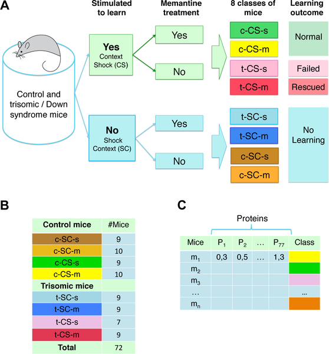

*Fig 1. Classes of mice. (A) There are eight classes of mice based on genotype (control, c, and trisomy, t), stimulation to learn (Context-Shock, CS, and Shock-Context, SC) and treatment (saline, s, and memantine, m). Learning outcome indicates the response to learning for each class. (B) Number of mice in each class. (C) Format of protein expression data: rows are individual mice, and columns, P 1 … P77, are the measured levels of the 77 proteins[^6].*

### RStudio Libraries

The libraries `rmarkdown`, `GGally`, `car`, `ggplot2`, `dplyr`, `gsheet`, `gridExtra`,`htmltools`, `reshape2`, `granova`, `psychometric`, `Hmisc`, `qwraps` & `outliers` were employed during the analysis.

### Data Set

The Excel file ‘Data_Cortex_Nuclear.xls’ was downloaded from UCI’s machine learning repository[^7] into Google Drive (s3644119 at RMIT University) and the imported into the R Studio interactive environment as “ds”.

```r
url <- "https://docs.google.com/spreadsheets/d/158zPd4XCYoaXNzHA2OJPkOmzSWYjwFoEuOiMzV1O-rU/edit?usp=sharing"
ds <- gsheet2tbl(url)
```

### Data Checking

The initial data checking is summarized below (functioning code in Appendix).

| Function | Purpose / Outcome |
| --- | --- |
| `summary(ds)` | Confirming the successful importation of the data set. Size was 1080 observations over 82 variables. The 77 protein attributes are continuous numerical data, with NaN values present. |
| `colnames(ds)` | Confirming the column names present in the data set. The first column is MouseID (12 - 15 observations per mouse, per protein). The final four columns contain the categorical data about each mouse. |
| `MouseID <- ds$MouseID` | Each mouseID is appended with the suffix ’_n’ (where 1 <- n <- 15). For example MouseID ‘309’ is recorded as 309_1, 309_2, … 309_15. |

### Data Preprocessing - Iteration 1

The native data set will be preprocessed in four iterations for use in our analysis. These data were collected such that they are all on the same scale (approximately 0 - 4) and are intended for direct comparison without any transformation (for example a value of 0.1 for protein A and 1.0 for protein B shows that protein B is expressed 10 times that of protein A). The only transformation performed on these data was column subtraction, for pair t-test analysis (see Data Preprocessing - Iteration 3).

#### Stripping the measurement count from each mouse

During data collection, per each individual mouse, per each protein, 12 - 15 expression measurements were taken *in vitro*. As mentioned in the summary above, these were denoted as ’_n’ (where 1 <- n <- 15). For the purpose of this investigation, the _n notation is not required, and will be stripped from the data. The function `table(head(ds$MouseID, 150))` samples the first 10 mice in the data set, showing successful removal of _n notation.

```r
MouseID <- gsub("\\_.*", "", ds$MouseID)
ds$MouseID <- MouseID
```

```r
table(head(ds$MouseID, 150))
```

```
 309  311  320  321  322 3415 3499 3507 3520 3521
  15   15   15   15   15   15   15   15   15   15
```

#### Selecting the target proteins & creating a new dataset

Through the use of self-organizing feature maps, Higuera et al were able to determine the most discriminant proteins in comparison of the control mice classes and the trisomic mice classes<sup>1</sup>. For this analysis, these tabulated results were assessed in a semi-quantitative fashion[^8] and the proteins ARC_N, BRAF_N, DYRK1A_N, ITSN1_N, pERK_N, pNUMB_N, S6_N & SOD1_N were selected. A vector of these identifiers was created as `target_attributes_proteins`. These target proteins, along with the categorical tags Genotype, Treatment, Behavior and class were added to another vector, `target_attributes_all`. A new data set, `ds_filtered` was then created, with the native data set observations for the variables of the `target_attributes_all` vector.

```r
target_attributes_proteins <- c("ARC_N", "BRAF_N", "DYRK1A_N", "ITSN1_N", "pERK_N",
    "pNUMB_N", "S6_N", "SOD1_N")
```

```r
target_attributes_all <- c("MouseID", "ARC_N", "BRAF_N", "DYRK1A_N", "ITSN1_N",
    "pERK_N", "pNUMB_N", "S6_N", "SOD1_N", "Genotype", "Treatment", "Behavior",
    "class")
```

```r
ds_filtered <- ds[, target_attributes_all]
```

#### Checking the data set ds_filtered

The categorical values in `ds_filtered` were checked with `unique(ds_filtered[,10:13])`, not typographical errors were present, as below.

```r
categorical_counts <- ds_filtered[, 10:13]
unique(categorical_counts)
```

| Genotype | Treatment | Behavior | class |
| --- | --- | --- | --- |
| Control | Memantine | C/S | c-CS-m |
| Control | Memantine | S/C | c-SC-m |
| Control | Saline | C/S | c-CS-s |
| Control | Saline | S/C | c-SC-s |
| Ts65Dn | Memantine | C/S | t-CS-m |
| Ts65Dn | Memantine | S/C | t-SC-m |
| Ts65Dn | Saline | C/S | t-CS-s |
| Ts65Dn | Saline | S/C | t-SC-s |

The categorical variable counts are summarized in the below (functions executed in Appendix).

| Function | Counts | Total |
| --- | --- | --- |
| `table(ds_filtered$Genotype)` | Control = 570, Ts65Dn = 510 | 1080 |
| `table(ds_filtered$Treatment)` | Memantine = 570, Saline = 510 | 1080 |
| `table(ds_filtered$Behavior)` | C/S = 525, S/C = 555 | 1080 |
| `table(ds_filtered$class)` | c-CS-m = 150, c-CS-s = 135, c-SC-m = 150, c-SC-s = 135, t-CS-m = 135, t-CS-s = 105, t-SC-m = 135, t-SC-s = 135 | 1080 |

### Data Preprocessing - Iteration 2

#### Locating NaN Values

The coordinate locations for NaN values are displayed below (the result output was transposed for readability). The expression `ds_filtered[c(988, 989, 990),c(1, 10, 11, 12, 13)]` was used to identify the mouse/mice and corresponding categories.

```r
t(which(is.na(ds_filtered), arr.ind = TRUE))
```

```
    [,1] [,2] [,3] [,4] [,5] [,6] [,7] [,8] [,9] [,10] [,11] [,12] [,13] [,14] [,15] [,16] [,17] [,18]
row  988  989  990  988  989  990  988  989  990   988   989   990   988   989   990   988   989   990
col    3    3    3    4    4    4    5    5    5     6     6     6     7     7     7     9     9     9
```

```r
ds_filtered[c(988, 989, 990), c(1, 10, 11, 12, 13)]
```

| MouseID | Genotype | Treatment | Behavior | class |
| --- | --- | --- | --- | --- |
| 3426 | Ts65Dn | Saline | S/C | t-SC-s |
| 3426 | Ts65Dn | Saline | S/C | t-SC-s |
| 3426 | Ts65Dn | Saline | S/C | t-SC-s |

#### Filling the NaN Values

```r
tSCs_filter <- ds_filtered$class == "t-SC-s"
NaN_column_mask <- c(3, 4, 5, 6, 7, 9)
NaN_3426_tSCs <- ds_filtered[tSCs_filter, NaN_column_mask]
summary_3426_tSCs <- summary(NaN_3426_tSCs)
summary_3426_tSCs
```

```
     BRAF_N          DYRK1A_N         ITSN1_N           pERK_N          pNUMB_N           SOD1_N
 Min.   :0.1940   Min.   :0.1633   Min.   :0.3284   Min.   :0.1492   Min.   :0.2352   Min.   :0.3841
 1st Qu.:0.2456   1st Qu.:0.2781   1st Qu.:0.4715   1st Qu.:0.2807   1st Qu.:0.2974   1st Qu.:0.5534
 Median :0.2844   Median :0.3479   Median :0.5519   Median :0.3552   Median :0.3591   Median :0.6467
 Mean   :0.2867   Mean   :0.3375   Mean   :0.5491   Mean   :0.3577   Mean   :0.3577   Mean   :0.7214
 3rd Qu.:0.3264   3rd Qu.:0.3916   3rd Qu.:0.6249   3rd Qu.:0.4412   3rd Qu.:0.4072   3rd Qu.:0.8075
 Max.   :0.4306   Max.   :0.5006   Max.   :0.8362   Max.   :0.5562   Max.   :0.5203   Max.   :1.6105
 NA's   :3        NA's   :3        NA's   :3        NA's   :3        NA's   :3        NA's   :3
```

```r
write.csv(ds_filtered, file = "mouse_data_filtered.csv")
ds_filled_NaN <- gsheet2tbl("https://docs.google.com/spreadsheets/d/1FKFINItxyosgFhwiihpT3MSuMTxR-LaYPNG_XNctwlU/edit?usp=sharing")
```

The filtered mouse data was exported using `write.csv` and added to Google Sheets. The NaN values were filled as follows BRAF_N = 0.2867, DYRK1A_N = 0.3375, ITSN1_N = 0.5491, pERK_N = 0.3577, pNUMB_N = 0.3577 and SOD1_N = 0.7214. The data set was then imported as `ds_Filled_NaN`. These data were checked for NaN as follows.

```r
NaN_check <- ds_filled_NaN[tSCs_filter, NaN_column_mask]
summary_NaN_check <- summary(NaN_check)
summary_NaN_check
```

```
     BRAF_N          DYRK1A_N         ITSN1_N           pERK_N          pNUMB_N           SOD1_N
 Min.   :0.1940   Min.   :0.1633   Min.   :0.3284   Min.   :0.1492   Min.   :0.2352   Min.   :0.3841
 1st Qu.:0.2467   1st Qu.:0.2785   1st Qu.:0.4755   1st Qu.:0.2823   1st Qu.:0.2996   1st Qu.:0.5536
 Median :0.2867   Median :0.3466   Median :0.5491   Median :0.3560   Median :0.3577   Median :0.6571
 Mean   :0.2867   Mean   :0.3375   Mean   :0.5491   Mean   :0.3577   Mean   :0.3577   Mean   :0.7214
 3rd Qu.:0.3252   3rd Qu.:0.3900   3rd Qu.:0.6243   3rd Qu.:0.4404   3rd Qu.:0.4070   3rd Qu.:0.8067
 Max.   :0.4306   Max.   :0.5006   Max.   :0.8362   Max.   :0.5562   Max.   :0.5203   Max.   :1.6105
```

| Mean Fill Summary | BRAF_N | DYRK1A_N | ITSN1_N | pERK_N | pNUMB_N | SOD1_N |
| --- | --- | --- | --- | --- | --- | --- |
| Native Data Mean | 0.2867 | 0.3375 | 0.5491 | 0.3577 | 0.3577 | 0.7214 |
| Preprocessed Data Mean | 0.2867 | 0.3375 | 0.5491 | 0.3577 | 0.3577 | 0.7214 |
| Delta Mean | 0.0000 | 0.0000 | 0.0000 | 0.0000 | 0.0000 | 0.0000 |

- All mean values remained the same to four decimal places.

### Data Exploration through Visualization

#### Scatter Plot Matrix

The preprocessed data will first be visualized with a scatter plot matrix using the `ggpairs` function. The upper section of the plot will be an xy contour, the lower an xy scatter and the diagonal density plots. A scatter plot matrix is a suitable at this stage as it gives a quantitative overview of these data and provides direction for further analysis.

- Note scatter plot matrix code will be displayed only once.

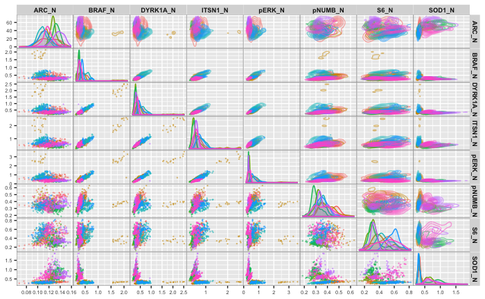

```r
scatter_matrix <- ggpairs(data = ds_filled_NaN, columns = target_attributes_proteins,
    mapping = aes(colour = class), diag = list(continuous = wrap("densityDiag",
        alpha = I(0.1)), mapping = ggplot2::aes(fill = class)), upper = list(continuous = wrap("density",
        alpha = I(0.5)), combo = "box"), lower = list(continuous = wrap("points",
        alpha = I(0.4), size = 0.1)))
scatter_matrix_adjusted <- scatter_matrix + theme(panel.spacing = grid::unit(0,
    "lines"), axis.text = element_text(size = rel(0.5)), strip.text = element_text(face = "bold",
    size = 7), strip.text.x = element_text(margin = margin(0.1, 0, 0.1, 0, "cm")),
    strip.text.y = element_text(margin = margin(0, 0.1, 0, 0.1, "cm")))
scatter_matrix_adjusted + theme(panel.border = element_rect(fill = NA, colour = "grey30",
    size = 0.2))
```

The resultant plot, shows six of the proteins to be correlated (qualitatively) in a linear fashion;

- DYRK1A_N vs BRAF_N
- ITSN1_N vs BRAF_N
- pERK_N vs BRAF_N
- ITSN1_N vs DYRK1A_N
- pERK_N vs DYRK1A_N
- pERK_N vs ITSN1_N

This will provide direction for subsequent statistical analysis.

Other trends noticeable include inversely proportional relationships (e.g., SOD1_N vs BRAF_N), weak correlation (e.g., pNUMB_N vs BRAF_N) and no correlation (e.g., pNUMB_N vs ARC_N). Also of note, in the columns ARC_N, BRAF_N, DYRK1A_N, ITSN1_N and pERK_N, a series of points (amber colour) are seen to lay outside the main clusters in every individual scatter plot. Bar charts for two target proteins exhibiting these outliers were plotted.

#### Bar Chart for pERK & BRAF

The resultant plots show clusters of outliers for the class, ‘c-CS-s’.

- Note box plot code will be displayed only once.

```r
BRAF_N_Hist <- ggplot(data = ds_filled_NaN, aes(x = ds_filled_NaN$class, y = BRAF_N,
    fill = ds_filled_NaN$class)) + geom_boxplot() + theme(legend.title = element_blank(),
    axis.title = element_text(size = 8)) + labs(title = NULL, x = "BRAF_N Expression",
    y = NULL) + guides(fill = FALSE) + coord_flip()
```

```r
pERK_N_Hist <- ggplot(data = ds_filled_NaN, aes(x = ds_filled_NaN$class, y = pERK_N,
    fill = ds_filled_NaN$class)) + geom_boxplot() + theme(legend.title = element_blank(),
    axis.title = element_text(size = 8)) + labs(title = NULL, x = "pERK_N Expression",
    y = NULL) + guides(fill = FALSE) + coord_flip()
```

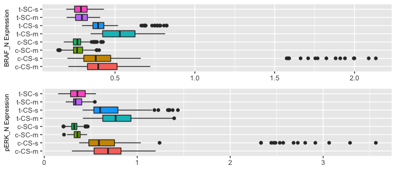

```r
grid.arrange(BRAF_N_Hist, pERK_N_Hist, nrow = 2)
```

The most extreme outlier for each protein was determined using the `outlier()` function, in conjunction with filtering.

```r
ds_filled_NaN[ds_filled_NaN$ARC_N == outlier(ds_filled_NaN$ARC_N), c(1, 2, 10,
    11, 12, 13)]
```

| MouseID | ARC_N | Genotype | Treatment | Behavior | class |
| --- | --- | --- | --- | --- | --- |
| 3415 | 0.06725429 | Control | Memantine | C/S | c-CS-m |

```r
ds_filled_NaN[ds_filled_NaN$BRAF_N == outlier(ds_filled_NaN$BRAF_N), c(1, 3,
    10, 11, 12, 13)]
```

| MouseID | BRAF_N | Genotype | Treatment | Behavior | class |
| --- | --- | --- | --- | --- | --- |
| 3484 | 2.133416 | Control | Saline | C/S | c-CS-s |

```r
ds_filled_NaN[ds_filled_NaN$DYRK1A_N == outlier(ds_filled_NaN$DYRK1A_N), c(1,
    4, 10, 11, 12, 13)]
```

| MouseID | DYRK1A_N | Genotype | Treatment | Behavior | class |
| --- | --- | --- | --- | --- | --- |
| 3484 | 2.516367 | Control | Saline | C/S | c-CS-s |

```r
ds_filled_NaN[ds_filled_NaN$ITSN1_N == outlier(ds_filled_NaN$ITSN1_N), c(1,
    5, 10, 11, 12, 13)]
```

| MouseID | ITSN1_N | Genotype | Treatment | Behavior | class |
| --- | --- | --- | --- | --- | --- |
| 3484 | 2.602662 | Control | Saline | C/S | c-CS-s |

```r
ds_filled_NaN[ds_filled_NaN$pERK_N == outlier(ds_filled_NaN$pERK_N), c(1, 6,
    10, 11, 12, 13)]
```

| MouseID | pERK_N | Genotype | Treatment | Behavior | class |
| --- | --- | --- | --- | --- | --- |
| 3484 | 3.566685 | Control | Saline | C/S | c-CS-s |

```r
ds_filled_NaN[ds_filled_NaN$pNUMB_N == outlier(ds_filled_NaN$pNUMB_N), c(1,
    7, 10, 11, 12, 13)]
```

| MouseID | pNUMB_N | Genotype | Treatment | Behavior | class |
| --- | --- | --- | --- | --- | --- |
| 3497 | 0.6310522 | Control | Saline | C/S | c-CS-s |

```r
ds_filled_NaN[ds_filled_NaN$S6_N == outlier(ds_filled_NaN$S6_N), c(1, 8, 10,
    11, 12, 13)]
```

| MouseID | S6_N | Genotype | Treatment | Behavior | class |
| --- | --- | --- | --- | --- | --- |
| 3483 | 0.8226108 | Ts65Dn | Saline | C/S | t-CS-s |

```r
ds_filled_NaN[ds_filled_NaN$SOD1_N == outlier(ds_filled_NaN$SOD1_N), c(1, 9,
    10, 11, 12, 13)]
```

| MouseID | SOD1_N | Genotype | Treatment | Behavior | class |
| --- | --- | --- | --- | --- | --- |
| 3411 | 1.872899 | Ts65Dn | Memantine | S/C | t-SC-m |

[output not shown]

- Mouse ID 3484 contributed 50% of the maximum outliers, and was dropped from the data set.

### Data Preprocessing - Iteration 3

#### Dropping MouseID 3484

```r
ds_filled_NaN <- ds_filled_NaN[!(ds_filled_NaN$MouseID == 3484),]
```

- This gives a resultant data set of size [13 variables by 1065 observations].

### Data Exploration through Visualization

#### Scatter Plot Matrix - MouseID 3484 dropped

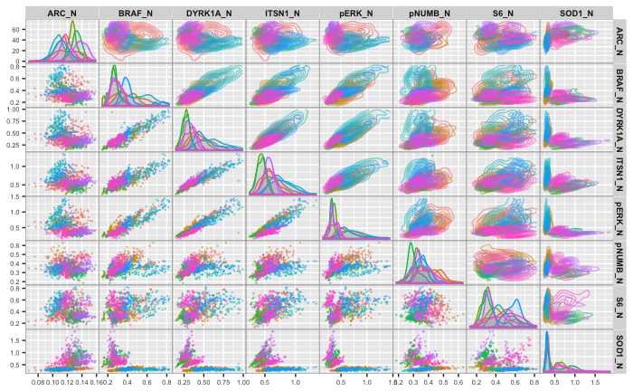

#### Box Plots for each Protein

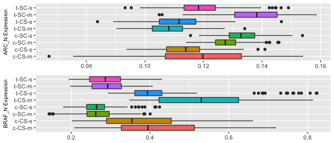

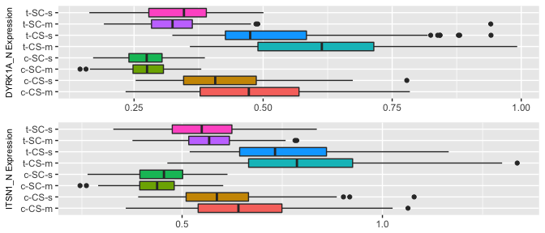

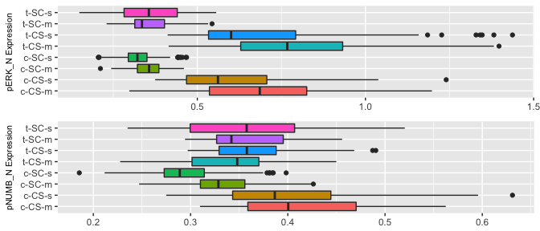

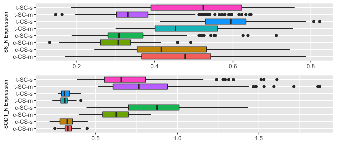

The bar plots were an excellent source of qualitative information. As demonstrated for ITSN1_N and SOD1_N, below.

[output not shown]

## Statistical Analysis Part 1 - Linear Regression and Correlation

Of the 6 previously mentioned pairs of qualitative linear relationships, three will be used for statistical analysis.

- ITSN1_N vs DYRK1A_N
- pERK_N vs DYRK1A_N
- pERK_N vs BRAF_N

For each pair of target proteins, all classes will be analyzed together. If linear relationships are statistically significant, this will indicate the dependent relationships are maintained over the changes in genotype, treatment and behaviour.

```r
target_attributes_linear <- c("BRAF_N", "DYRK1A_N", "ITSN1_N", "pERK_N")
```

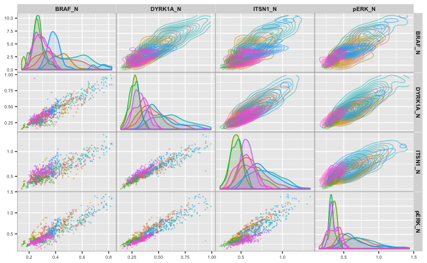

### ITSN1_N vs DYRK1A_N

#### Fitting the Data to a Linear Regression Model

- H0: Accross all eight classes of mice, the expression of ITSN1_N was not linearly dependent to the expression of DYRK1A_N
- HA: Accross all eight classes of mice, the expression of ITSN1_N was linearly dependent to the expression of DYRK1A_N

```r
ITSN1_N_VS_DYRK1A_N <- lm(ITSN1_N ~ DYRK1A_N, data = ds_filled_NaN)
ITSN1_N_VS_DYRK1A_N %>% summary()
```

```
Call:
lm(formula = ITSN1_N ~ DYRK1A_N, data = ds_filled_NaN)

Residuals:
     Min       1Q   Median       3Q      Max
-0.54552 -0.04070 -0.00268  0.03774  0.24657

Coefficients:
            Estimate Std. Error t value Pr(>|t|)
(Intercept) 0.178032   0.005445   32.70   <2e-16 ***
DYRK1A_N    1.037442   0.012600   82.34   <2e-16 ***
---
Signif. codes:  0 ‘***’ 0.001 ‘**’ 0.01 ‘*’ 0.05 ‘.’ 0.1 ‘ ’ 1

Residual standard error: 0.0643 on 1063 degrees of freedom
Multiple R-squared:  0.8645,    Adjusted R-squared:  0.8643
F-statistic:  6779 on 1 and 1063 DF,  p-value: < 2.2e-16
```

```r
ITSN1_N_VS_DYRK1A_N %>% anova()
```

```
Analysis of Variance Table

Response: ITSN1_N
            Df  Sum Sq Mean Sq F value    Pr(>F)
DYRK1A_N     1 28.0244 28.0244  6779.2 < 2.2e-16 ***
Residuals 1063  4.3943  0.0041
---
Signif. codes:  0 ‘***’ 0.001 ‘**’ 0.01 ‘*’ 0.05 ‘.’ 0.1 ‘ ’ 1
```

- The p-value of the observed F statistic was found to be 2.2e-16. As p is less than the 0.05 level of significance, we reject H0.

#### The Constant, or Intercept Value

- H0:α=0
- HA:α≠0

```r
ITSN1_N_VS_DYRK1A_N %>% summary() %>% coef()
```

```
             Estimate  Std. Error  t value      Pr(>|t|)
(Intercept) 0.1780317 0.005445164 32.69538 7.787868e-163
DYRK1A_N    1.0374418 0.012600150 82.33567  0.000000e+00
```

- t = 32.696, p < 0.001  
  The constant is statistically significant at the 0.05 level. This means that there is statistically significant evidence that the constant is not 0. Their would always be some amount of the target proteins being expressed.

```r
ITSN1_N_VS_DYRK1A_N %>% confint()
```

```
                2.5 %    97.5 %
(Intercept) 0.1673472 0.1887162
DYRK1A_N    1.0127178 1.0621658
```

- 95% CI for the Intercept is found to be [0.167, 0.189]  
  H0:α=0 is not captured by this interval, so was rejected.

#### The Slope

- H0:β=0
- HA:β≠0

```r
2 * pt(q = 82.33567, df = 1063, lower.tail = FALSE)
```

```
[1] 0
```

As p < .05, we reject H0. The 95% CI for b was found to [1.013, 1.062]. This 95% CI does not capture H0, therefore it was rejected.

There was a statistically significant positive relationship between the expression of DYRK1A_N and ITSN1_N.

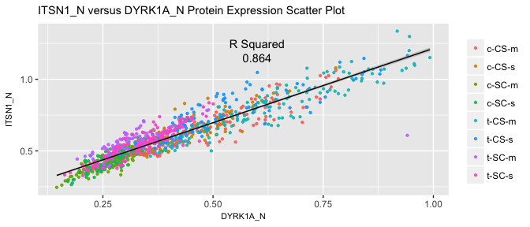

```r
ITSN1_N_VS_DYRK1A_N_XY <- ggplot(data = ds_filled_NaN, aes(x = DYRK1A_N, y = ITSN1_N,
    colour = class))
ITSN1_N_VS_DYRK1A_N_XY + geom_point(alpha = I(0.9), size = 0.8) + stat_smooth(method = "lm",
    col = "black", size = 0.5) + labs(title = "ITSN1_N versus DYRK1A_N Protein Expression Scatter Plot",
    y = "ITSN1_N", x = "DYRK1A_N") + theme(legend.title = element_blank(), axis.title = element_text(size = 8),
    title = element_text(size = 9)) + annotate("text", x = 0.6, y = 1.25, label = "R Squared") +
    annotate("text", x = 0.6, y = 1.15, label = format(summary(lm(ITSN1_N ~
        DYRK1A_N, data = ds_filled_NaN))$r.squared, digits = 3))
```

### pERK_N vs DYRK1A_N

#### Fitting the Data to a Linear Regression Model

- H0: Accross all eight classes of mice, the expression of pERK_N was not linearly dependent to the expression of DYRK1A_N
- HA: Accross all eight classes of mice, the expression of pERK_N was linearly dependent to the expression of DYRK1A_N

```r
pERK_N_VS_DYRK1A_N <- lm(pERK_N ~ DYRK1A_N, data = ds_filled_NaN)
pERK_N_VS_DYRK1A_N %>% summary()
```

```
Call:
lm(formula = pERK_N ~ DYRK1A_N, data = ds_filled_NaN)

Residuals:
     Min       1Q   Median       3Q      Max
-0.94073 -0.05411 -0.00875  0.05405  0.31963

Coefficients:
             Estimate Std. Error t value Pr(>|t|)
(Intercept) -0.048086   0.007251  -6.631 5.28e-11 ***
DYRK1A_N     1.401485   0.016779  83.524  < 2e-16 ***
---
Signif. codes:  0 ‘***’ 0.001 ‘**’ 0.01 ‘*’ 0.05 ‘.’ 0.1 ‘ ’ 1

Residual standard error: 0.08562 on 1063 degrees of freedom
Multiple R-squared:  0.8678,    Adjusted R-squared:  0.8677
F-statistic:  6976 on 1 and 1063 DF,  p-value: < 2.2e-16
```

```r
pERK_N_VS_DYRK1A_N %>% anova()
```

```
Analysis of Variance Table

Response: pERK_N
            Df Sum Sq Mean Sq F value    Pr(>F)
DYRK1A_N     1 51.143  51.143  6976.3 < 2.2e-16 ***
Residuals 1063  7.793   0.007
---
Signif. codes:  0 ‘***’ 0.001 ‘**’ 0.01 ‘*’ 0.05 ‘.’ 0.1 ‘ ’ 1
```

- The p-value of the observed F statistic was found to be 2.2e-16. As p is less than the 0.05 level of significance, we reject H0.

#### The Constant, or Intercept Value

- H0:α=0
- HA:α≠0

```r
pERK_N_VS_DYRK1A_N %>% summary() %>% coef()
```

```
             Estimate  Std. Error   t value     Pr(>|t|)
(Intercept) -0.048086 0.007251214 -6.631441 5.280216e-11
DYRK1A_N     1.401485 0.016779364 83.524345 0.000000e+00
```

```r
pERK_N_VS_DYRK1A_N %>% confint()
```

```
                  2.5 %      97.5 %
(Intercept) -0.06231432 -0.03385768
DYRK1A_N     1.36856094  1.43440981
```

- 95% CI for the Intercept is found to be [-0.062, -0.034]  
  H0:α=0 is not captured by this interval, so was rejected.

#### The Slope

- H0:β=0
- HA:β≠0

```r
2 * pt(q = 83.524345, df = 1063, lower.tail = FALSE)
```

```
[1] 0
```

As p < .05, we reject H0. The 95% CI for b was found to [1.369, 1.434]. This 95% CI does not capture H0, therefore it was rejected.

There was a statistically significant positive relationship between the expression of pERK_N and DYRK1A_N.

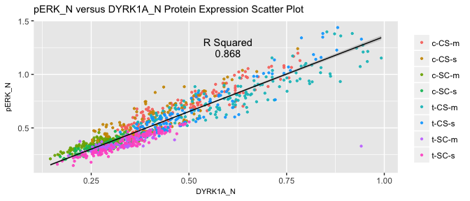

```r
pERK_N_VS_DYRK1A_N_XY <- ggplot(data = ds_filled_NaN, aes(x = DYRK1A_N, y = pERK_N,
    colour = class))
pERK_N_VS_DYRK1A_N_XY + geom_point(alpha = I(0.9), size = 0.8) + stat_smooth(method = "lm",
    col = "black", size = 0.5) + labs(title = "pERK_N versus DYRK1A_N Protein Expression Scatter Plot",
    y = "pERK_N", x = "DYRK1A_N") + theme(legend.title = element_blank(), axis.title = element_text(size = 8),
    title = element_text(size = 9)) + annotate("text", x = 0.6, y = 1.3, label = "R Squared") +
    annotate("text", x = 0.6, y = 1.2, label = format(summary(lm(pERK_N ~ DYRK1A_N,
        data = ds_filled_NaN))$r.squared, digits = 3))
```

### pERK_N vs BRAF_N

#### Fitting the Data to a Linear Regression Model

- H0: Accross all eight classes of mice, the expression of pERK_N was not linearly dependent to the expression of BRAF_N
- HA: Accross all eight classes of mice, the expression of pERK_N was linearly dependent to the expression of BRAF_N

```r
pERK_N_VS_BRAF_N <- lm(pERK_N ~ BRAF_N, data = ds_filled_NaN)
pERK_N_VS_BRAF_N %>% summary()
```

```
Call:
lm(formula = pERK_N ~ BRAF_N, data = ds_filled_NaN)

Residuals:
     Min       1Q   Median       3Q      Max
-0.30232 -0.06317 -0.00958  0.04958  0.42462

Coefficients:
             Estimate Std. Error t value Pr(>|t|)
(Intercept) -0.066629   0.009219  -7.228 9.37e-13 ***
BRAF_N       1.629637   0.024215  67.299  < 2e-16 ***
---
Signif. codes:  0 ‘***’ 0.001 ‘**’ 0.01 ‘*’ 0.05 ‘.’ 0.1 ‘ ’ 1

Residual standard error: 0.1027 on 1063 degrees of freedom
Multiple R-squared:  0.8099,    Adjusted R-squared:  0.8097
F-statistic:  4529 on 1 and 1063 DF,  p-value: < 2.2e-16
```

```r
pERK_N_VS_BRAF_N %>% anova()
```

```
Analysis of Variance Table

Response: pERK_N
            Df Sum Sq Mean Sq F value    Pr(>F)
BRAF_N       1 47.733  47.733  4529.1 < 2.2e-16 ***
Residuals 1063 11.203   0.011
---
Signif. codes:  0 ‘***’ 0.001 ‘**’ 0.01 ‘*’ 0.05 ‘.’ 0.1 ‘ ’ 1
```

- The p-value of the observed F statistic was found to be 2.2e-16. As p is less than the 0.05 level of significance, we reject H0.

#### The Constant, or Intercept Value

- H0:α=0
- HA:α≠0

```r
pERK_N_VS_BRAF_N %>% summary() %>% coef()
```

```
               Estimate  Std. Error  t value     Pr(>|t|)
(Intercept) -0.06662867 0.009218592 -7.22764 9.369867e-13
BRAF_N       1.62963697 0.024214953 67.29879 0.000000e+00
```

```r
pERK_N_VS_BRAF_N %>% confint()
```

```
                  2.5 %      97.5 %
(Intercept) -0.08471737 -0.04853996
BRAF_N       1.58212243  1.67715150
```

- 95% CI for the Intercept is found to be [-0.085, -0.049]  
  H0:α=0 is not captured by this interval, so was rejected.

#### The Slope

- H0:β=0
- HA:β≠0

```r
2 * pt(q = 67.29879, df = 1063, lower.tail = FALSE)
```

```
[1] 0
```

As p < .05, we reject H0. The 95% CI for b was found to [1.582, 1.677]. This 95% CI does not capture H0, therefore it was rejected.

There was a statistically significant positive relationship between the expression of pERK_N and BRAF_N.

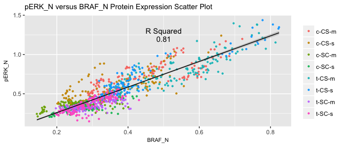

### Data Preprocessing - Iteration 4

#### Creating Columns for Paired t-test Analysis

The following columns were created using the `mutate()` function. All classes were then dropped except ‘c-CS-s’ (this corresponds to the control group with normal genotype, saline treatment and CS learning).

```r
ds_filled_NaN <- ds_filled_NaN %>% mutate(d_ARC_BRAF = BRAF_N - ARC_N)
ds_filled_NaN <- ds_filled_NaN %>% mutate(d_BRAF_DYRK1A = DYRK1A_N - BRAF_N)
ds_filled_NaN <- ds_filled_NaN %>% mutate(d_DYRK1A_ITSN1 = ITSN1_N - DYRK1A_N)
ds_filled_NaN <- ds_filled_NaN %>% mutate(d_ITSN1_pERK = pERK_N - ITSN1_N)
ds_filled_NaN <- ds_filled_NaN %>% mutate(d_pERK_pNUMB = pNUMB_N - pERK_N)
ds_filled_NaN <- ds_filled_NaN %>% mutate(d_pNUMB_S6 = S6_N - pNUMB_N)
ds_filled_NaN <- ds_filled_NaN %>% mutate(d_S6_SOD1 = SOD1_N - S6_N)
```

```r
ds_cCSs <- ds_filled_NaN[(ds_filled_NaN$class == "c-CS-s"), ]
```

## Statistical Analysis Part 2 - Paired two-sample t-tests

Analysis was conducted for 7 pairs of protein expression levels in all mice from the class ‘c-CS-s’. These were considered dependent (paired) samples as the mice from each individual class were all exposed to the same set of variables.

#### Critical Value - All Paris

```r
qt(p = 0.025, df = 119)
```

```
[1] -1.9801
```

### ARC_N & BRAF_N for c-CS-s

```r
t.test(ds_cCSs$d_ARC_BRAF, mu = 0, alternative = "two.sided")
```

```
    One Sample t-test

data:  ds_cCSs$d_ARC_BRAF
t = 27.724, df = 119, p-value < 2.2e-16
alternative hypothesis: true mean is not equal to 0
95 percent confidence interval:
 0.2377760 0.2743528
sample estimates:
mean of x
0.2560644
```

```
            Summary Stats
n                 120.000
mean(x)             0.114
mean(y)             0.370
mean(D=x-y)        -0.256
SD(D)               0.101
ES(D)              -2.531
r(x,y)             -0.096
r(x+y,d)           -0.983
LL 95%CI           -0.274
UL 95%CI           -0.238
t(D-bar)          -27.724
df.t              119.000
pval.t              0.000
```

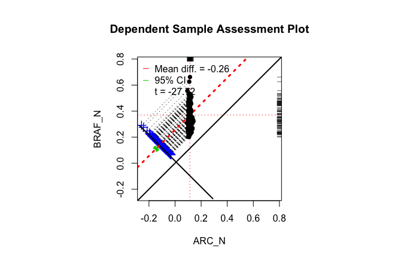

```r
granova.ds(data.frame(ds_cCSs$ARC_N, ds_cCSs$BRAF_N), xlab = "ARC_N", ylab = "BRAF_N")
```

The t* values are ± 1.98. As t = 27.72 is more extreme than + 1.98, H0 should be rejected (additionally the 95% CI of the mean difference is found to be [0.24 0.27], which does not contain capture H0). There was a statistically significant mean difference between the expression of ARC_N and BRAF_N for the c-CS-s (n = 120).

### BRAF_N & DYRK1A_N for c-CS-s

```r
t.test(ds_cCSs$d_BRAF_DYRK1A, mu = 0, alternative = "two.sided")
```

```
    One Sample t-test

data:  ds_cCSs$d_BRAF_DYRK1A
t = 8.8709, df = 119, p-value = 8.741e-15
alternative hypothesis: true mean is not equal to 0
95 percent confidence interval:
 0.03654614 0.05754950
sample estimates:
 mean of x
0.04704782
```

```
            Summary Stats
n                 120.000
mean(x)             0.370
mean(y)             0.417
mean(D=x-y)        -0.047
SD(D)               0.058
ES(D)              -0.810
r(x,y)              0.828
r(x+y,d)            0.028
LL 95%CI           -0.058
UL 95%CI           -0.037
t(D-bar)           -8.871
df.t              119.000
pval.t              0.000
```

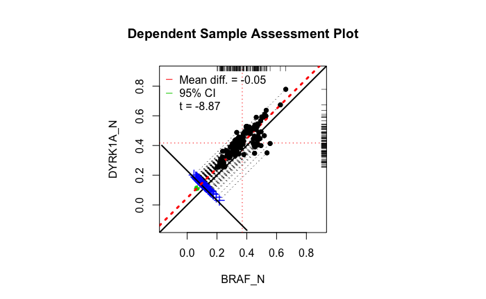

```r
granova.ds(data.frame(ds_cCSs$BRAF_N, ds_cCSs$DYRK1A_N), xlab = "BRAF_N", ylab = "DYRK1A_N")
```

The t* values are ± 1.98. As t = 8.87 is more extreme than + 1.98, H0 should be rejected (additionally the 95% CI of the mean difference is found to be [0.04 0.06], which does not contain capture H0). There was a statistically significant mean difference between the expression of BRAF_N and DYRK1A_N for the c-CS-s (n = 120).

### DYRK1A_N & ITSN1_N for c-CS-s

```r
t.test(ds_cCSs$d_DYRK1A_ITSN1, mu = 0, alternative = "two.sided")
```

```
    One Sample t-test

data:  ds_cCSs$d_DYRK1A_ITSN1
t = 34.216, df = 119, p-value < 2.2e-16
alternative hypothesis: true mean is not equal to 0
95 percent confidence interval:
 0.1784135 0.2003316
sample estimates:
mean of x
0.1893725
```

```
            Summary Stats
n                 120.000
mean(x)             0.417
mean(y)             0.606
mean(D=x-y)        -0.189
SD(D)               0.061
ES(D)              -3.123
r(x,y)              0.887
r(x+y,d)           -0.493
LL 95%CI           -0.200
UL 95%CI           -0.178
t(D-bar)          -34.216
df.t              119.000
pval.t              0.000
```

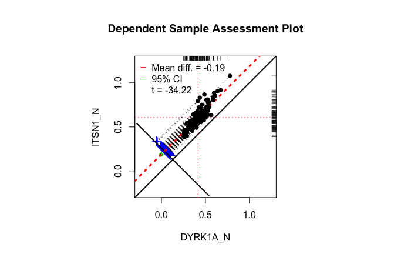

```r
granova.ds(data.frame(ds_cCSs$DYRK1A_N, ds_cCSs$ITSN1_N), xlab = "DYRK1A_N",
    ylab = "ITSN1_N")
```

The t* values are ± 1.98. As t = 34.22 is more extreme than + 1.98, H0 should be rejected (additionally the 95% CI of the mean difference is found to be [0.18 0.20], which does not contain capture H0). There was a statistically significant mean difference between the expression of DYRK1A_N and ITSN1_N for the c-CS-s (n = 120).

### ITSN1_N & pERK_N for c-CS-s

```r
t.test(ds_cCSs$d_ITSN1_pERK, mu = 0, alternative = "two.sided")
```

```
    One Sample t-test

data:  ds_cCSs$d_ITSN1_pERK
t = -0.69643, df = 119, p-value = 0.4875
alternative hypothesis: true mean is not equal to 0
95 percent confidence interval:
 -0.02289979  0.01098278
sample estimates:
   mean of x
-0.005958507
```

```
            Summary Stats
n                 120.000
mean(x)             0.606
mean(y)             0.600
mean(D=x-y)         0.006
SD(D)               0.094
ES(D)               0.064
r(x,y)              0.835
r(x+y,d)           -0.458
LL 95%CI           -0.011
UL 95%CI            0.023
t(D-bar)            0.696
df.t              119.000
pval.t              0.488
```

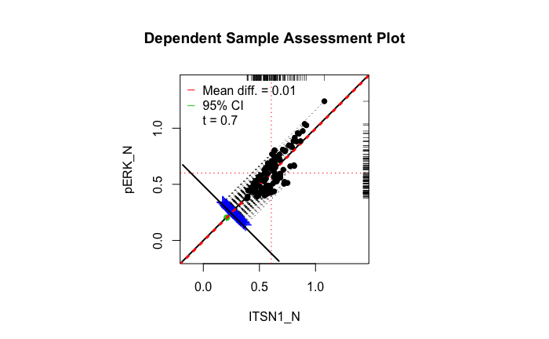

```r
granova.ds(data.frame(ds_cCSs$ITSN1_N, ds_cCSs$pERK_N), xlab = "ITSN1_N", ylab = "pERK_N")
```

The t* values are ± 1.98. As t = -0.70, t is less extreme than than -1.98, H0 cannot be rejected on critical value. The 95% CI of the mean difference is found to be [-0.02 0.01], H0 cannot be rejected on 95% CI. As p > 0.05, we fail to reject H0. There was not a statistically significant mean difference between the expression of ITSN1_N and pERK_N for the c-CS-s (n = 120).

### pERK_N & pNUMB_N for c-CS-s

```r
t.test(ds_cCSs$d_pERK_pNUMB, mu = 0, alternative = "two.sided")
```

```
    One Sample t-test

data:  ds_cCSs$d_pERK_pNUMB
t = -16.569, df = 119, p-value < 2.2e-16
alternative hypothesis: true mean is not equal to 0
95 percent confidence interval:
 -0.2236380 -0.1758912
sample estimates:
 mean of x
-0.1997646
```

```
            Summary Stats
n                 120.000
mean(x)             0.600
mean(y)             0.400
mean(D=x-y)         0.200
SD(D)               0.132
ES(D)               1.513
r(x,y)              0.667
r(x+y,d)            0.793
LL 95%CI            0.176
UL 95%CI            0.224
t(D-bar)           16.569
df.t              119.000
pval.t              0.000
```

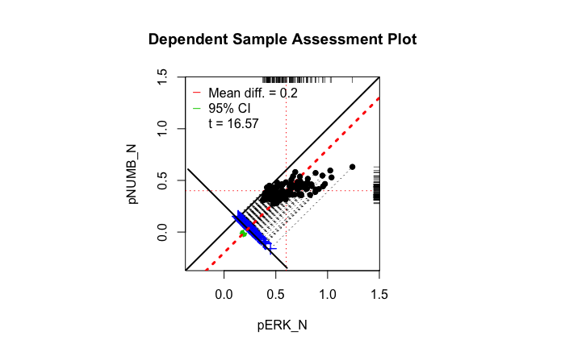

```r
granova.ds(data.frame(ds_cCSs$pERK_N, ds_cCSs$pNUMB_N), xlab = "pERK_N", ylab = "pNUMB_N")
```

The t* values are ± 1.98. As t = -16.57 is more extreme than - 1.98, H0 should be rejected (additionally the 95% CI of the mean difference is found to be [-0.22 -0.18], which does not contain capture H0). There was a statistically significant mean difference between the expression of pERK_N and pNUMB_N for the c-CS-s (n = 120).

### pNUMB_N & S6_N for c-CS-s

```r
t.test(ds_cCSs$d_pNUMB_S6, mu = 0, alternative = "two.sided")
```

```
    One Sample t-test

data:  ds_cCSs$d_pNUMB_S6
t = 3.892, df = 119, p-value = 0.0001644
alternative hypothesis: true mean is not equal to 0
95 percent confidence interval:
 0.02379530 0.07308288
sample estimates:
 mean of x
0.04843909
```

```
            Summary Stats
n                 120.000
mean(x)             0.400
mean(y)             0.449
mean(D=x-y)        -0.048
SD(D)               0.136
ES(D)              -0.355
r(x,y)              0.123
r(x+y,d)           -0.513
LL 95%CI           -0.073
UL 95%CI           -0.024
t(D-bar)           -3.892
df.t              119.000
pval.t              0.000
```

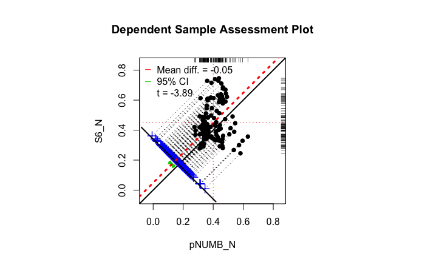

```r
granova.ds(data.frame(ds_cCSs$pNUMB_N, ds_cCSs$S6_N), xlab = "pNUMB_N", ylab = "S6_N")
```

The t* values are ± 1.98. As t = 3.89 is more extreme than + 1.98, H0 should be rejected (additionally the 95% CI of the mean difference is found to be [0.02 0.07], which does not contain capture H0). There was a statistically significant mean difference between the expression of pNUMB_N and S6_N for the c-CS-s (n = 120).

### S6_N & SOD1_N for c-CS-s

```r
t.test(ds_cCSs$d_S6_SOD1, mu = 0, alternative = "two.sided")
```

```
    One Sample t-test

data:  ds_cCSs$d_S6_SOD1
t = -10.45, df = 119, p-value < 2.2e-16
alternative hypothesis: true mean is not equal to 0
95 percent confidence interval:
 -0.1482443 -0.1010126
sample estimates:
 mean of x
-0.1246285
```

```
            Summary Stats
n                 120.000
mean(x)             0.449
mean(y)             0.324
mean(D=x-y)         0.125
SD(D)               0.131
ES(D)               0.954
r(x,y)              0.101
r(x+y,d)            0.709
LL 95%CI            0.101
UL 95%CI            0.148
t(D-bar)           10.450
df.t              119.000
pval.t              0.000
```

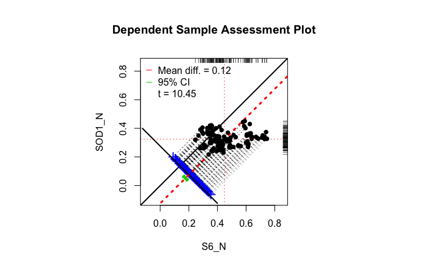

```r
granova.ds(data.frame(ds_cCSs$S6_N, ds_cCSs$SOD1_N), xlab = "S6_N", ylab = "SOD1_N")
```

The t* values are ± 1.98. As t = -10.45 is more extreme than - 1.98, H0 should be rejected (additionally the 95% CI of the mean difference is found to be [-0.15 -0.10], which does not contain capture H0). There was a statistically significant mean difference between the expression of S6_N and SOD1_N for the c-CS-s (n = 120).

### Discussion

The following was determined over the duration of the investigation,

- ITSN1_N vs DYRK1A_N (over all classes of mice) had a statistically significant linearly dependent positive relationship.
- pERK_N vs DYRK1A_N (over all classes of mice) had a statistically significant linearly dependent positive relationship.
- pERK_N vs BRAF_N (over all classes of mice) had a statistically significant linearly dependent positive relationship.

This is signficant as it shows the relationship between these expression of proteins is nto affected by the variables of the experiment.

- There was a statistically significant mean difference between the expression of ARC_N and BRAF_N for the c-CS-s.
- There was a statistically significant mean difference between the expression of BRAF_N and DYRK1A_N for the c-CS-s.
- There was a statistically significant mean difference between the expression of DYRK1A_N and ITSN1_N for the c-CS-s.
- There was not a statistically significant mean difference between the expression of ITSN1_N and pERK_N for the c-CS-s.
- There was a statistically significant mean difference between the expression of pERK_N and pNUMB_N for the c-CS-s.
- There was a statistically significant mean difference between the expression of pNUMB_N and S6_N for the c-CS-s.
- There was a statistically significant mean difference between the expression of S6_N and SOD1_N for the c-CS-s.

The strengths of the investigation included high sample size (overall and in sub-categories), use of various visualizations for data exploration and interprettation, different statistical analysis methods. Limitations included the complex nature of the data set. For example only 7 paired t-tests could reasonably be performed. For the class c-CS-s, this doesn’t represent every possible combination. Comparisons between classes inside individual target proteins would have also been a rich source of data.

### References (see last page)

### Appendix - Not considered for grading

```r
summary(ds)
```

```
   MouseID             DYRK1A_N         ITSN1_N           BDNF_N           NR1_N           NR2A_N
 Length:1080        Min.   :0.1453   Min.   :0.2454   Min.   :0.1152   Min.   :1.331   Min.   :1.738
 Class :character   1st Qu.:0.2881   1st Qu.:0.4734   1st Qu.:0.2874   1st Qu.:2.057   1st Qu.:3.156
 Mode  :character   Median :0.3664   Median :0.5658   Median :0.3166   Median :2.297   Median :3.761
                    Mean   :0.4258   Mean   :0.6171   Mean   :0.3191   Mean   :2.297   Mean   :3.844
                    3rd Qu.:0.4877   3rd Qu.:0.6980   3rd Qu.:0.3482   3rd Qu.:2.528   3rd Qu.:4.440
                    Max.   :2.5164   Max.   :2.6027   Max.   :0.4972   Max.   :3.758   Max.   :8.483
                    NA's   :3        NA's   :3        NA's   :3        NA's   :3       NA's   :3
     pAKT_N           pBRAF_N          pCAMKII_N        pCREB_N           pELK_N          pERK_N
 Min.   :0.06324   Min.   :0.06404   Min.   :1.344   Min.   :0.1128   Min.   :0.429   Min.   :0.1492
 1st Qu.:0.20575   1st Qu.:0.16459   1st Qu.:2.480   1st Qu.:0.1908   1st Qu.:1.204   1st Qu.:0.3374
 Median :0.23118   Median :0.18230   Median :3.327   Median :0.2106   Median :1.356   Median :0.4436
 Mean   :0.23317   Mean   :0.18185   Mean   :3.537   Mean   :0.2126   Mean   :1.429   Mean   :0.5459
 3rd Qu.:0.25726   3rd Qu.:0.19742   3rd Qu.:4.482   3rd Qu.:0.2346   3rd Qu.:1.561   3rd Qu.:0.6633
 Max.   :0.53905   Max.   :0.31707   Max.   :7.464   Max.   :0.3062   Max.   :6.113   Max.   :3.5667
 NA's   :3         NA's   :3         NA's   :3       NA's   :3        NA's   :3       NA's   :3
     pJNK_N            PKCA_N           pMEK_N            pNR1_N          pNR2A_N          pNR2B_N
 Min.   :0.05211   Min.   :0.1914   Min.   :0.05682   Min.   :0.5002   Min.   :0.2813   Min.   :0.3016
 1st Qu.:0.28124   1st Qu.:0.2818   1st Qu.:0.24429   1st Qu.:0.7435   1st Qu.:0.5903   1st Qu.:1.3813
 Median :0.32133   Median :0.3130   Median :0.27739   Median :0.8211   Median :0.7196   Median :1.5637
 Mean   :0.31351   Mean   :0.3179   Mean   :0.27503   Mean   :0.8258   Mean   :0.7269   Mean   :1.5620
 3rd Qu.:0.34871   3rd Qu.:0.3523   3rd Qu.:0.30345   3rd Qu.:0.8985   3rd Qu.:0.8486   3rd Qu.:1.7485
 Max.   :0.49343   Max.   :0.4740   Max.   :0.45800   Max.   :1.4082   Max.   :1.4128   Max.   :2.7240
 NA's   :3         NA's   :3        NA's   :3         NA's   :3        NA's   :3        NA's   :3
    pPKCAB_N          pRSK_N            AKT_N             BRAF_N          CAMKII_N          CREB_N
 Min.   :0.5678   Min.   :0.09594   Min.   :0.06442   Min.   :0.1439   Min.   :0.2130   Min.   :0.1136
 1st Qu.:1.1683   1st Qu.:0.40414   1st Qu.:0.59682   1st Qu.:0.2643   1st Qu.:0.3309   1st Qu.:0.1618
 Median :1.3657   Median :0.44060   Median :0.68247   Median :0.3267   Median :0.3603   Median :0.1796
 Mean   :1.5253   Mean   :0.44285   Mean   :0.68224   Mean   :0.3785   Mean   :0.3634   Mean   :0.1805
 3rd Qu.:1.8859   3rd Qu.:0.48210   3rd Qu.:0.75969   3rd Qu.:0.4136   3rd Qu.:0.3939   3rd Qu.:0.1957
 Max.   :3.0614   Max.   :0.65096   Max.   :1.18217   Max.   :2.1334   Max.   :0.5862   Max.   :0.3196
 NA's   :3        NA's   :3         NA's   :3         NA's   :3        NA's   :3        NA's   :3
     ELK_N            ERK_N          GSK3B_N           JNK_N            MEK_N            TRKA_N
 Min.   :0.4977   Min.   :1.132   Min.   :0.1511   Min.   :0.0463   Min.   :0.1472   Min.   :0.1987
 1st Qu.:0.9444   1st Qu.:1.992   1st Qu.:1.0231   1st Qu.:0.2204   1st Qu.:0.2471   1st Qu.:0.6171
 Median :1.0962   Median :2.401   Median :1.1598   Median :0.2449   Median :0.2734   Median :0.7050
 Mean   :1.1734   Mean   :2.474   Mean   :1.1726   Mean   :0.2416   Mean   :0.2728   Mean   :0.6932
 3rd Qu.:1.3236   3rd Qu.:2.873   3rd Qu.:1.3097   3rd Qu.:0.2633   3rd Qu.:0.3008   3rd Qu.:0.7742
 Max.   :2.8029   Max.   :5.198   Max.   :2.4758   Max.   :0.3872   Max.   :0.4154   Max.   :1.0016
 NA's   :18       NA's   :3       NA's   :3        NA's   :3        NA's   :7        NA's   :3
```

[output cut: 53 more lines]

```
 3rd Qu.:1.3631   3rd Qu.:0.9162   3rd Qu.:0.2417   3rd Qu.:0.1740   3rd Qu.:0.14823   3rd Qu.:0.13196
 Max.   :1.8972   Max.   :1.2046   Max.   :0.3583   Max.   :0.2820   Max.   :0.26151   Max.   :0.15875
                                                    NA's   :213      NA's   :285
    pCFOS_N            SYP_N          H3AcK18_N           EGR1_N          H3MeK4_N          CaNA_N
 Min.   :0.08542   Min.   :0.2586   Min.   :0.07969   Min.   :0.1055   Min.   :0.1018   Min.   :0.5865
 1st Qu.:0.11351   1st Qu.:0.3981   1st Qu.:0.12585   1st Qu.:0.1551   1st Qu.:0.1651   1st Qu.:1.0814
 Median :0.12652   Median :0.4485   Median :0.15824   Median :0.1749   Median :0.1940   Median :1.3174
 Mean   :0.13105   Mean   :0.4461   Mean   :0.16961   Mean   :0.1831   Mean   :0.2054   Mean   :1.3378
 3rd Qu.:0.14365   3rd Qu.:0.4908   3rd Qu.:0.19788   3rd Qu.:0.2045   3rd Qu.:0.2352   3rd Qu.:1.5858
 Max.   :0.25653   Max.   :0.7596   Max.   :0.47976   Max.   :0.3607   Max.   :0.4139   Max.   :2.1298
 NA's   :75                         NA's   :180       NA's   :210      NA's   :270
   Genotype          Treatment           Behavior            class
 Length:1080        Length:1080        Length:1080        Length:1080
 Class :character   Class :character   Class :character   Class :character
 Mode  :character   Mode  :character   Mode  :character   Mode  :character
```

```r
colnames(ds)
```

```
 [1] "MouseID"         "DYRK1A_N"        "ITSN1_N"         "BDNF_N"          "NR1_N"
 [6] "NR2A_N"          "pAKT_N"          "pBRAF_N"         "pCAMKII_N"       "pCREB_N"
[11] "pELK_N"          "pERK_N"          "pJNK_N"          "PKCA_N"          "pMEK_N"
[16] "pNR1_N"          "pNR2A_N"         "pNR2B_N"         "pPKCAB_N"        "pRSK_N"
[21] "AKT_N"           "BRAF_N"          "CAMKII_N"        "CREB_N"          "ELK_N"
[26] "ERK_N"           "GSK3B_N"         "JNK_N"           "MEK_N"           "TRKA_N"
[31] "RSK_N"           "APP_N"           "Bcatenin_N"      "SOD1_N"          "MTOR_N"
[36] "P38_N"           "pMTOR_N"         "DSCR1_N"         "AMPKA_N"         "NR2B_N"
[41] "pNUMB_N"         "RAPTOR_N"        "TIAM1_N"         "pP70S6_N"        "NUMB_N"
[46] "P70S6_N"         "pGSK3B_N"        "pPKCG_N"         "CDK5_N"          "S6_N"
[51] "ADARB1_N"        "AcetylH3K9_N"    "RRP1_N"          "BAX_N"           "ARC_N"
[56] "ERBB4_N"         "nNOS_N"          "Tau_N"           "GFAP_N"          "GluR3_N"
[61] "GluR4_N"         "IL1B_N"          "P3525_N"         "pCASP9_N"        "PSD95_N"
[66] "SNCA_N"          "Ubiquitin_N"     "pGSK3B_Tyr216_N" "SHH_N"           "BAD_N"
[71] "BCL2_N"          "pS6_N"           "pCFOS_N"         "SYP_N"           "H3AcK18_N"
[76] "EGR1_N"          "H3MeK4_N"        "CaNA_N"          "Genotype"        "Treatment"
[81] "Behavior"        "class"
```

```r
MouseID
```

[output not shown]

[output cut: 111 more lines]

```r
table(ds_filtered$Genotype)
```

```
Control  Ts65Dn
    570     510
```

```r
table(ds_filtered$Treatment)
```

```
Memantine    Saline
      570       510
```

```r
table(ds_filtered$Behavior)
```

```
C/S S/C
525 555
```

```r
table(ds_filtered$class)
```

```
c-CS-m c-CS-s c-SC-m c-SC-s t-CS-m t-CS-s t-SC-m t-SC-s
   150    135    150    135    135    105    135    135
```

[^1]: Higuera, C., Gardiner, K. J., & Cios, K. J. (2015). Self-Organizing Feature Maps Identyfy Proteins Critical to Learning in a Mouse Model of Down Syndrome. PLoS ONE, 10(6).
[^2]: Ahmed, M. M., Dhanasekaran, A. R., Block, A., Tong, S., Costa, A. C. S., Stasko, M., & Gardiner, K. J. (2014). Protein Dynamics Associated with Failed and Rescues Learning in the TS65Dn Mouse Model of Down Syndrome. PLoS ONE, 10(3).
[^3]: Costa, A., Scott-McKean, J., & Stasko, M. (2008). Acute injections of the NMDA receptor antagonist memantine rescue performance deficits of the Ts65Dn mouse model of Down syndrome on a fear conditioning test. Neuropsychopharmacology, 33(7), 1624-1632.
[^4]: Davisson, M., Schmidt, C., Reeves, R., Irving, N., Akeson, E., Harris, B., & Bronson, R. (1993). Segmental trisomy as a mouse model for Down syndrome. Prog Clin Biol Res, 384, 117-133.
[^5]: Mitra, A., Blank, M., & Madison, D. (2012). Developmentally altered inhibition in Ts65Dn, a mouse model of Down syndrome. Brain Research, 1440, 1-8.
[^6]: http://journals.plos.org/plosone/article/figure/image?size=medium&id=10.1371/journal.pone.0129126.g001
[^7]: http://archive.ics.uci.edu/ml/
[^8]: https://docs.google.com/spreadsheets/d/1scXPvhOh3kmANCAhf1X_CLwJQckOJA-WMP_f9lHVri4/edit?usp=sharing, CONTROL MICE PROTEINS http://www.plosone.org/article/fetchSingleRepresentation.action?uri=info:doi/10.1371/journal.pone.0129126.s003, TRISOMIC MICE PROTEINS, http://www.plosone.org/article/fetchSingleRepresentation.action?uri=info:doi/10.1371/journal.pone.0129126.s004